# A Global Study of COVID-19 Effects vs Dietary Composition (CMSC320 Final Tutorial)

By: Danesh Sivakumar

*“Health requires healthy food."*

- Roger Williams (1603 – 1683) [he lived a pretty long time!]

## Introduction

The COVID-19 pandemic has brought about unprecedented times; the extremely rapid spread of the disease during 2019-2020 was devastating worldwide. Particularly affected were countries with low socioeconomic standing; due to mass panic and a lack of reliable information, many individuals in these countries were unable to take proper precautions and thus unfortunately suffered adverse consequences. It is no coincidence that many of these countries that were affected are also burdened by another pandemic: food insecurity.

Having been raised in a rural village in India, my father was no stranger to nights without dinner. Droughts and a lack of access to clean drinking water certainly didn't contribute positively to his family's hunger. In spite of the fact that it has been over forty years since those times, not much has improved. Many people in developing countries are in food deserts, and do not have access to reliable healthy sources of food; as such, they are forced to either starve or make do with unhealthy sustenance. World hunger has been a problem for decades now, but it is an especially pressing matter at this time and day.

In this project, I aim to investigate deeper this trend between food habits and different COVID-19 statistics, conditined on country. In particular, I want to look for trends in the data and establish statistically significant results that demonstrate relationships between the aforementioned parameters.

## 1: Data Collection/Curation

### 1.A: Libraries

First, we need to import the necessary libraries:

- `pandas`: lets us use dataframes to manipulate and display the data
- `numpy`: helps us perform computationally efficient array operations
- `matplotlib`: allows for effective data visualization
- `statsmodels`: lets us perform statistical tests and measure the significance of our results

```python
import pandas as pd
import numpy as np
import matplotlib.pyplot as plt
import statsmodels.api as sm
import statsmodels.formula.api as smf
```

### 1.B: Data

The datasets I used are from Kaggle; one of the datasets contain information about the average dietary composition of individuals in many different countries, and the other dataset contains COVID statistics conditioned on country. Links to the dataset are attached at the end of the document.

Let's read in the data now

```python
df_fat_supply = pd.read_csv('Fat_Supply_Quantity_Data.csv', usecols=range(26), low_memory=False)

df_fat_supply
```

|  | Country | Alcoholic Beverages | Animal Products | Animal fats | Aquatic Products, Other | Cereals - Excluding Beer | Eggs | Fish, Seafood | Fruits - Excluding Wine | Meat | ... | Starchy Roots | Stimulants | Sugar Crops | Sugar & Sweeteners | Treenuts | Vegetal Products | Vegetable Oils | Vegetables | Obesity | Undernourished |
| --- | --- | --- | --- | --- | --- | --- | --- | --- | --- | --- | --- | --- | --- | --- | --- | --- | --- | --- | --- | --- | --- |
| 0 | Afghanistan | 0.0000 | 21.6397 | 6.2224 | 0.0 | 8.0353 | 0.6859 | 0.0327 | 0.4246 | 6.1244 | ... | 0.0490 | 0.0980 | 0.0000 | 0.0 | 0.7513 | 28.3684 | 17.0831 | 0.3593 | 4.5 | 29.8 |
| 1 | Albania | 0.0000 | 32.0002 | 3.4172 | 0.0 | 2.6734 | 1.6448 | 0.1445 | 0.6418 | 8.7428 | ... | 0.0510 | 0.5270 | 0.0000 | 0.0 | 0.9181 | 17.9998 | 9.2443 | 0.6503 | 22.3 | 6.2 |
| 2 | Algeria | 0.0000 | 14.4175 | 0.8972 | 0.0 | 4.2035 | 1.2171 | 0.2008 | 0.5772 | 3.8961 | ... | 0.1129 | 0.2886 | 0.0000 | 0.0 | 0.8595 | 35.5857 | 27.3606 | 0.5145 | 26.6 | 3.9 |
| 3 | Angola | 0.0000 | 15.3041 | 1.3130 | 0.0 | 6.5545 | 0.1539 | 1.4155 | 0.3488 | 11.0268 | ... | 0.7078 | 0.1128 | 0.0000 | 0.0 | 0.0308 | 34.7010 | 22.4638 | 0.1231 | 6.8 | 25 |
| 4 | Antigua and Barbuda | 0.0000 | 27.7033 | 4.6686 | 0.0 | 3.2153 | 0.3872 | 1.5263 | 1.2177 | 14.3202 | ... | 0.0449 | 1.0549 | 0.0000 | 0.0 | 0.2020 | 22.2995 | 14.4436 | 0.2469 | 19.1 | NaN |
| ... | ... | ... | ... | ... | ... | ... | ... | ... | ... | ... | ... | ... | ... | ... | ... | ... | ... | ... | ... | ... | ... |
| 165 | Venezuela (Bolivarian Republic of) | 0.0000 | 16.3261 | 2.2673 | 0.0 | 2.5449 | 0.6555 | 0.5707 | 0.9640 | 7.0949 | ... | 0.1311 | 0.0848 | 0.0000 | 0.0 | 0.0154 | 33.6855 | 29.5211 | 0.1851 | 25.2 | 21.2 |
| 166 | Vietnam | 0.0000 | 33.2484 | 3.8238 | 0.0 | 3.7155 | 0.7839 | 1.1217 | 0.4079 | 26.4292 | ... | 0.0701 | 0.0829 | 0.0382 | 0.0 | 1.1726 | 16.7548 | 5.6211 | 0.6373 | 2.1 | 9.3 |
| 167 | Yemen | 0.0000 | 12.5401 | 2.0131 | 0.0 | 11.5271 | 0.5514 | 0.3847 | 0.2564 | 8.0010 | ... | 0.0513 | 0.3718 | 0.0000 | 0.0 | 0.0769 | 37.4535 | 23.6312 | 0.1667 | 14.1 | 38.9 |
| 168 | Zambia | 0.0783 | 9.6005 | 1.6113 | 0.0 | 14.3225 | 0.6266 | 1.0070 | 0.1343 | 4.9010 | ... | 0.2014 | 0.0671 | 0.0000 | 0.0 | 0.0112 | 40.3939 | 15.2848 | 0.1567 | 6.5 | 46.7 |
| 169 | Zimbabwe | 0.0000 | 10.3796 | 2.9543 | 0.0 | 9.7922 | 0.3682 | 0.2455 | 0.0614 | 4.5674 | ... | 0.0877 | 0.1052 | 0.0000 | 0.0 | 0.4296 | 39.6248 | 26.9396 | 0.0789 | 12.3 | 51.3 |

170 rows × 26 columns

As we can see, this data set contains information about the fat composition of the average individual's diet, conditioned on country; the units are percentage of diet. As an example, 21.63% of Afghanistan's fat intake comes from Animal Products. We also have the obesity and undernutrition percentages.

```python
df_food_supply = pd.read_csv('Food_Supply_Quantity_kg_Data.csv', usecols=range(26), low_memory=False)

df_food_supply
```

|  | Country | Alcoholic Beverages | Animal fats | Animal Products | Aquatic Products, Other | Cereals - Excluding Beer | Eggs | Fish, Seafood | Fruits - Excluding Wine | Meat | ... | Starchy Roots | Stimulants | Sugar & Sweeteners | Sugar Crops | Treenuts | Vegetable Oils | Vegetables | Vegetal Products | Obesity | Undernourished |
| --- | --- | --- | --- | --- | --- | --- | --- | --- | --- | --- | --- | --- | --- | --- | --- | --- | --- | --- | --- | --- | --- |
| 0 | Afghanistan | 0.0014 | 0.1973 | 9.4341 | 0.0000 | 24.8097 | 0.2099 | 0.0350 | 5.3495 | 1.2020 | ... | 0.8802 | 0.3078 | 1.3489 | 0.000 | 0.0770 | 0.5345 | 6.7642 | 40.5645 | 4.5 | 29.8 |
| 1 | Albania | 1.6719 | 0.1357 | 18.7684 | 0.0000 | 5.7817 | 0.5815 | 0.2126 | 6.7861 | 1.8845 | ... | 1.8096 | 0.1055 | 1.5367 | 0.000 | 0.1515 | 0.3261 | 11.7753 | 31.2304 | 22.3 | 6.2 |
| 2 | Algeria | 0.2711 | 0.0282 | 9.6334 | 0.0000 | 13.6816 | 0.5277 | 0.2416 | 6.3801 | 1.1305 | ... | 4.1340 | 0.2216 | 1.8342 | 0.000 | 0.1152 | 1.0310 | 11.6484 | 40.3651 | 26.6 | 3.9 |
| 3 | Angola | 5.8087 | 0.0560 | 4.9278 | 0.0000 | 9.1085 | 0.0587 | 1.7707 | 6.0005 | 2.0571 | ... | 18.1102 | 0.0508 | 1.8495 | 0.000 | 0.0061 | 0.6463 | 2.3041 | 45.0722 | 6.8 | 25 |
| 4 | Antigua and Barbuda | 3.5764 | 0.0087 | 16.6613 | 0.0000 | 5.9960 | 0.2274 | 4.1489 | 10.7451 | 5.6888 | ... | 1.4522 | 0.1564 | 3.8749 | 0.000 | 0.0253 | 0.8102 | 5.4495 | 33.3233 | 19.1 | NaN |
| ... | ... | ... | ... | ... | ... | ... | ... | ... | ... | ... | ... | ... | ... | ... | ... | ... | ... | ... | ... | ... | ... |
| 165 | Venezuela (Bolivarian Republic of) | 2.5952 | 0.0403 | 14.7565 | 0.0000 | 12.9253 | 0.3389 | 0.9456 | 7.6460 | 3.8328 | ... | 2.5643 | 0.1479 | 3.4106 | 0.000 | 0.0009 | 1.3734 | 4.1474 | 35.2416 | 25.2 | 21.2 |
| 166 | Vietnam | 1.4591 | 0.1640 | 8.5765 | 0.0042 | 16.8740 | 0.3077 | 2.6392 | 5.9029 | 4.4382 | ... | 1.0596 | 0.2880 | 1.2846 | 0.815 | 0.3070 | 0.2201 | 11.9508 | 41.4232 | 2.1 | 9.3 |
| 167 | Yemen | 0.0364 | 0.0446 | 5.7874 | 0.0000 | 27.2077 | 0.2579 | 0.5240 | 5.1344 | 2.7871 | ... | 1.0794 | 0.2199 | 5.0468 | 0.000 | 0.0017 | 1.0811 | 3.2135 | 44.2126 | 14.1 | 38.9 |
| 168 | Zambia | 5.7360 | 0.0829 | 6.0197 | 0.0000 | 21.1938 | 0.3399 | 1.6924 | 1.0183 | 1.8427 | ... | 7.9649 | 0.0618 | 1.5632 | 0.000 | 0.0014 | 0.6657 | 3.4649 | 43.9789 | 6.5 | 46.7 |
| 169 | Zimbabwe | 4.0552 | 0.0755 | 8.1489 | 0.0000 | 22.6240 | 0.2678 | 0.5518 | 2.2000 | 2.6142 | ... | 2.9870 | 0.1494 | 4.6485 | 0.000 | 0.0518 | 1.7103 | 2.3213 | 41.8526 | 12.3 | 51.3 |

170 rows × 26 columns

This data set contains slightly different information; it contains information about the percentage of *total* food composition in diet. As an example, 24.8% of the average Afganistan resident's diet is comprised of Cereals - Excluding Beer.

```python
df_protein_supply = pd.read_csv('Protein_Supply_Quantity_Data.csv', usecols=range(26), low_memory=False)

df_protein_supply
```

|  | Country | Alcoholic Beverages | Animal Products | Animal fats | Aquatic Products, Other | Cereals - Excluding Beer | Eggs | Fish, Seafood | Fruits - Excluding Wine | Meat | ... | Stimulants | Sugar Crops | Sugar & Sweeteners | Treenuts | Vegetal Products | Vegetable Oils | Vegetables | Miscellaneous | Obesity | Undernourished |
| --- | --- | --- | --- | --- | --- | --- | --- | --- | --- | --- | --- | --- | --- | --- | --- | --- | --- | --- | --- | --- | --- |
| 0 | Afghanistan | 0.0000 | 9.7523 | 0.0277 | 0.0000 | 35.9771 | 0.4067 | 0.0647 | 0.5824 | 3.1337 | ... | 0.5546 | 0.0000 | 0.0000 | 0.1387 | 40.2477 | 0.0000 | 1.1370 | 0.0462 | 4.5 | 29.8 |
| 1 | Albania | 0.1840 | 27.7469 | 0.0711 | 0.0000 | 14.2331 | 1.8069 | 0.6274 | 1.2757 | 7.6582 | ... | 0.2635 | 0.0000 | 0.0042 | 0.2677 | 22.2552 | 0.0084 | 3.2456 | 0.0544 | 22.3 | 6.2 |
| 2 | Algeria | 0.0323 | 13.8360 | 0.0054 | 0.0000 | 26.5633 | 1.2916 | 0.6350 | 1.1624 | 3.5088 | ... | 0.4628 | 0.0000 | 0.0000 | 0.2745 | 36.1694 | 0.0269 | 3.1267 | 0.1399 | 26.6 | 3.9 |
| 3 | Angola | 0.6285 | 15.2311 | 0.0277 | 0.0000 | 20.3882 | 0.1756 | 5.4436 | 1.2754 | 7.6248 | ... | 0.1017 | 0.0000 | 0.0092 | 0.0092 | 34.7782 | 0.0092 | 0.8133 | 0.0924 | 6.8 | 25 |
| 4 | Antigua and Barbuda | 0.1535 | 33.1901 | 0.1289 | 0.0000 | 10.5108 | 0.4850 | 8.2146 | 1.2586 | 16.0670 | ... | 0.4113 | 0.0000 | 0.0000 | 0.0737 | 16.8161 | 0.0430 | 1.6024 | 0.2947 | 19.1 | NaN |
| ... | ... | ... | ... | ... | ... | ... | ... | ... | ... | ... | ... | ... | ... | ... | ... | ... | ... | ... | ... | ... | ... |
| 165 | Venezuela (Bolivarian Republic of) | 0.1955 | 22.5411 | 0.1244 | 0.0000 | 21.6526 | 0.8707 | 2.6477 | 1.0662 | 11.8347 | ... | 0.3287 | 0.0000 | 0.0178 | 0.0000 | 27.4545 | 0.0533 | 1.0129 | 0.0267 | 25.2 | 21.2 |
| 166 | Vietnam | 0.1555 | 20.4466 | 0.1555 | 0.0056 | 18.5247 | 0.7665 | 5.7435 | 0.7165 | 11.0426 | ... | 0.5444 | 0.0167 | 0.0056 | 0.3277 | 29.5617 | 0.0000 | 3.7216 | 0.0389 | 2.1 | 9.3 |
| 167 | Yemen | 0.0000 | 10.0122 | 0.0188 | 0.0000 | 35.1179 | 0.4320 | 0.9392 | 0.4884 | 5.9453 | ... | 0.3193 | 0.0000 | 0.0000 | 0.0188 | 39.9831 | 0.0000 | 0.5448 | 0.0564 | 14.1 | 38.9 |
| 168 | Zambia | 0.4824 | 9.8925 | 0.0338 | 0.0000 | 28.5182 | 0.5839 | 3.0126 | 0.0931 | 4.3158 | ... | 0.0762 | 0.0000 | 0.0000 | 0.0000 | 40.1117 | 0.0000 | 0.8039 | 0.0592 | 6.5 | 46.7 |
| 169 | Zimbabwe | 0.2929 | 11.3443 | 0.0391 | 0.0000 | 33.1934 | 0.5077 | 1.0837 | 0.2636 | 6.6582 | ... | 0.2636 | 0.0000 | 0.0000 | 0.1367 | 38.6508 | 0.0293 | 0.5955 | 0.0586 | 12.3 | 51.3 |

170 rows × 26 columns

Finally, this dataset contains information about the percentage of protein from different food sources in diet. As an example, the average Albanian citizen gets 27.7% of their protein intake from Animal Products.

```python
df_supply_food_info = pd.read_csv('Supply_Food_Data_Descriptions.csv', low_memory=False)

df_supply_food_info
```

|  | Categories | Items |
| --- | --- | --- |
| 0 | Alcoholic Beverages | Alcohol, Non-Food; Beer; Beverages, Alcoholic;... |
| 1 | Animal fats | Butter, Ghee; Cream; Fats, Animals, Raw; Fish,... |
| 2 | Animal Products | Aquatic Animals, Others; Aquatic Plants; Bovin... |
| 3 | Aquatic Products, Other | Aquatic Animals, Others; Aquatic Plants; Meat,... |
| 4 | Cereals - Excluding Beer | Barley and products; Cereals, Other; Maize and... |
| 5 | Eggs | Eggs |
| 6 | Fish, Seafood | Cephalopods; Crustaceans; Demersal Fish; Fresh... |
| 7 | Fruits - Excluding Wine | Apples and products; Bananas; Citrus, Other; D... |
| 8 | Meat | Bovine Meat; Meat, Other; Mutton & Goat Meat; ... |
| 9 | Milk - Excluding Butter | Milk - Excluding Butter |
| 10 | Miscellaneous | Infant food; Miscellaneous |
| 11 | Offals | Offals, Edible |
| 12 | Oilcrops | Coconuts - Incl Copra; Cottonseed; Groundnuts ... |
| 13 | Pulses | Beans; Peas; Pulses, Other and products |
| 14 | Spices | Cloves; Pepper; Pimento; Spices, Other |
| 15 | Starchy Roots | Cassava and products; Potatoes and products; R... |
| 16 | Stimulants | Cocoa Beans and products; Coffee and products;... |
| 17 | Sugar & Sweeteners | Honey; Sugar (Raw Equivalent); Sugar non-centr... |
| 18 | Sugar Crops | Sugar beet; Sugar cane |
| 19 | Treenuts | Nuts and products |
| 20 | Vegetable Oils | Coconut Oil; Cottonseed Oil; Groundnut Oil; Ma... |
| 21 | Vegetables | Onions; Tomatoes and products; Vegetables, Other |
| 22 | Vegetal Products | Alcohol, Non-Food; Apples and products; Banana... |

This dataframe is mainly for reference later on; it contains specific food items that would be considered to be a part of the larger categories that are considered above.

```python
df_covid = pd.read_csv('country_wise_latest.csv', usecols=range(5), low_memory=False)

df_covid
```

|  | Country/Region | Confirmed | Deaths | Recovered | Active |
| --- | --- | --- | --- | --- | --- |
| 0 | Afghanistan | 36263 | 1269 | 25198 | 9796 |
| 1 | Albania | 4880 | 144 | 2745 | 1991 |
| 2 | Algeria | 27973 | 1163 | 18837 | 7973 |
| 3 | Andorra | 907 | 52 | 803 | 52 |
| 4 | Angola | 950 | 41 | 242 | 667 |
| ... | ... | ... | ... | ... | ... |
| 182 | West Bank and Gaza | 10621 | 78 | 3752 | 6791 |
| 183 | Western Sahara | 10 | 1 | 8 | 1 |
| 184 | Yemen | 1691 | 483 | 833 | 375 |
| 185 | Zambia | 4552 | 140 | 2815 | 1597 |
| 186 | Zimbabwe | 2704 | 36 | 542 | 2126 |

187 rows × 5 columns

Our last dataframe contains information about COVID cases, including the number of confirmed cases, deaths, and recovered individuals. All of these are important metrics that hold valuable information.

It's time to tidy the data upn now!

## 2. Data Management/Representation

We can observe that a lot of the information is redundant; for starters, let's put the obesity and undernutritioned data into its own dataframe, and get rid of it from each of the original ones. Without loss of generality, we can pull from the fat supply data.

```python
obesity_list = ['Obesity', 'Undernourished']
df_obesity = df_fat_supply[obesity_list]
df_fat_supply.drop(columns=obesity_list, inplace=True)
df_food_supply.drop(columns=obesity_list, inplace=True)
df_protein_supply.drop(columns=obesity_list, inplace=True)
df_obesity
```

|  | Obesity | Undernourished |
| --- | --- | --- |
| 0 | 4.5 | 29.8 |
| 1 | 22.3 | 6.2 |
| 2 | 26.6 | 3.9 |
| 3 | 6.8 | 25 |
| 4 | 19.1 | NaN |
| ... | ... | ... |
| 165 | 25.2 | 21.2 |
| 166 | 2.1 | 9.3 |
| 167 | 14.1 | 38.9 |
| 168 | 6.5 | 46.7 |
| 169 | 12.3 | 51.3 |

170 rows × 2 columns

Great! Another possible problem is that a lot of our column names are the same, which could lead to issues down the line when trying to access columns whose names are the same. Let's fix that!

```python
duplicate_names = list(df_fat_supply.columns) # getting all of the column names
```

```python
fat_supply_names = duplicate_names.copy()
food_supply_names = duplicate_names.copy()
protein_supply_names = duplicate_names.copy()

for i in range(1, len(duplicate_names)):
    fat_supply_names[i] = duplicate_names[i] + " (FAT)"
    food_supply_names[i] = duplicate_names[i] + " (FOOD)"
    protein_supply_names[i] = duplicate_names[i] + " (PROTEIN)"

column_dict_fat = dict(zip(duplicate_names, fat_supply_names))
column_dict_food = dict(zip(duplicate_names, food_supply_names))
column_dict_protein = dict(zip(duplicate_names, protein_supply_names))

df_fat_supply.rename(columns=column_dict_fat, inplace=True)
df_food_supply.rename(columns=column_dict_food, inplace=True)
df_protein_supply.rename(columns=column_dict_protein, inplace=True)

display(df_fat_supply.columns)
display(df_food_supply.columns)
display(df_protein_supply.columns) # nice!
```

```
Index(['Country', 'Alcoholic Beverages (FAT)', 'Animal Products (FAT)',
       'Animal fats (FAT)', 'Aquatic Products, Other (FAT)',
       'Cereals - Excluding Beer (FAT)', 'Eggs (FAT)', 'Fish, Seafood (FAT)',
       'Fruits - Excluding Wine (FAT)', 'Meat (FAT)', 'Miscellaneous (FAT)',
       'Milk - Excluding Butter (FAT)', 'Offals (FAT)', 'Oilcrops (FAT)',
       'Pulses (FAT)', 'Spices (FAT)', 'Starchy Roots (FAT)',
       'Stimulants (FAT)', 'Sugar Crops (FAT)', 'Sugar & Sweeteners (FAT)',
       'Treenuts (FAT)', 'Vegetal Products (FAT)', 'Vegetable Oils (FAT)',
       'Vegetables (FAT)'],
      dtype='object')
```

```
Index(['Country', 'Alcoholic Beverages (FOOD)', 'Animal fats (FOOD)',
       'Animal Products (FOOD)', 'Aquatic Products, Other (FOOD)',
       'Cereals - Excluding Beer (FOOD)', 'Eggs (FOOD)',
       'Fish, Seafood (FOOD)', 'Fruits - Excluding Wine (FOOD)', 'Meat (FOOD)',
       'Milk - Excluding Butter (FOOD)', 'Miscellaneous (FOOD)',
       'Offals (FOOD)', 'Oilcrops (FOOD)', 'Pulses (FOOD)', 'Spices (FOOD)',
       'Starchy Roots (FOOD)', 'Stimulants (FOOD)',
       'Sugar & Sweeteners (FOOD)', 'Sugar Crops (FOOD)', 'Treenuts (FOOD)',
       'Vegetable Oils (FOOD)', 'Vegetables (FOOD)',
       'Vegetal Products (FOOD)'],
      dtype='object')
```

```
Index(['Country', 'Alcoholic Beverages (PROTEIN)', 'Animal Products (PROTEIN)',
       'Animal fats (PROTEIN)', 'Aquatic Products, Other (PROTEIN)',
       'Cereals - Excluding Beer (PROTEIN)', 'Eggs (PROTEIN)',
       'Fish, Seafood (PROTEIN)', 'Fruits - Excluding Wine (PROTEIN)',
       'Meat (PROTEIN)', 'Milk - Excluding Butter (PROTEIN)',
       'Offals (PROTEIN)', 'Oilcrops (PROTEIN)', 'Pulses (PROTEIN)',
       'Spices (PROTEIN)', 'Starchy Roots (PROTEIN)', 'Stimulants (PROTEIN)',
       'Sugar Crops (PROTEIN)', 'Sugar & Sweeteners (PROTEIN)',
       'Treenuts (PROTEIN)', 'Vegetal Products (PROTEIN)',
       'Vegetable Oils (PROTEIN)', 'Vegetables (PROTEIN)',
       'Miscellaneous (PROTEIN)'],
      dtype='object')
```

We can now merge these dataframes into one dataframe to work with; we will still keep the old ones, but it would be nice to consolidate all our data. We also want to combine the COVID data as well, and it would be cumbersome to merge it with each one of the dataframes as opposed to merging them all together.

```python
df_supply = pd.merge(df_fat_supply, df_food_supply, on='Country')
df_supply = pd.merge(df_supply, df_protein_supply, on='Country')

# We need to rename the COVID dataframe's country column
# Upon examination, the US is named differently in both sets; let's fix this:

df_covid['Country/Region'] = df_covid['Country/Region'].apply(lambda x: 'United States of America' if x == 'US' else x)

df_covid.rename(columns={'Country/Region': 'Country'}, inplace=True)

df = pd.merge(df_covid, df_supply, on='Country')

display(df)
```

|  | Country | Confirmed | Deaths | Recovered | Active | Alcoholic Beverages (FAT) | Animal Products (FAT) | Animal fats (FAT) | Aquatic Products, Other (FAT) | Cereals - Excluding Beer (FAT) | ... | Spices (PROTEIN) | Starchy Roots (PROTEIN) | Stimulants (PROTEIN) | Sugar Crops (PROTEIN) | Sugar & Sweeteners (PROTEIN) | Treenuts (PROTEIN) | Vegetal Products (PROTEIN) | Vegetable Oils (PROTEIN) | Vegetables (PROTEIN) | Miscellaneous (PROTEIN) |
| --- | --- | --- | --- | --- | --- | --- | --- | --- | --- | --- | --- | --- | --- | --- | --- | --- | --- | --- | --- | --- | --- |
| 0 | Afghanistan | 36263 | 1269 | 25198 | 9796 | 0.0000 | 21.6397 | 6.2224 | 0.0 | 8.0353 | ... | 0.1664 | 0.1941 | 0.5546 | 0.0000 | 0.0000 | 0.1387 | 40.2477 | 0.0000 | 1.1370 | 0.0462 |
| 1 | Albania | 4880 | 144 | 2745 | 1991 | 0.0000 | 32.0002 | 3.4172 | 0.0 | 2.6734 | ... | 0.0000 | 0.8867 | 0.2635 | 0.0000 | 0.0042 | 0.2677 | 22.2552 | 0.0084 | 3.2456 | 0.0544 |
| 2 | Algeria | 27973 | 1163 | 18837 | 7973 | 0.0000 | 14.4175 | 0.8972 | 0.0 | 4.2035 | ... | 0.1776 | 1.4638 | 0.4628 | 0.0000 | 0.0000 | 0.2745 | 36.1694 | 0.0269 | 3.1267 | 0.1399 |
| 3 | Angola | 950 | 41 | 242 | 667 | 0.0000 | 15.3041 | 1.3130 | 0.0 | 6.5545 | ... | 0.0000 | 5.1941 | 0.1017 | 0.0000 | 0.0092 | 0.0092 | 34.7782 | 0.0092 | 0.8133 | 0.0924 |
| 4 | Antigua and Barbuda | 86 | 3 | 65 | 18 | 0.0000 | 27.7033 | 4.6686 | 0.0 | 3.2153 | ... | 0.3438 | 0.4666 | 0.4113 | 0.0000 | 0.0000 | 0.0737 | 16.8161 | 0.0430 | 1.6024 | 0.2947 |
| ... | ... | ... | ... | ... | ... | ... | ... | ... | ... | ... | ... | ... | ... | ... | ... | ... | ... | ... | ... | ... | ... |
| 148 | Uzbekistan | 21209 | 121 | 11674 | 9414 | 0.0000 | 25.9903 | 2.4884 | 0.0 | 2.7168 | ... | 0.0160 | 1.2509 | 0.1604 | 0.0000 | 0.0000 | 0.1657 | 29.9781 | 0.0053 | 3.9985 | 0.0321 |
| 149 | Vietnam | 431 | 0 | 365 | 66 | 0.0000 | 33.2484 | 3.8238 | 0.0 | 3.7155 | ... | 0.5221 | 0.2333 | 0.5444 | 0.0167 | 0.0056 | 0.3277 | 29.5617 | 0.0000 | 3.7216 | 0.0389 |
| 150 | Yemen | 1691 | 483 | 833 | 375 | 0.0000 | 12.5401 | 2.0131 | 0.0 | 11.5271 | ... | 0.0657 | 0.2066 | 0.3193 | 0.0000 | 0.0000 | 0.0188 | 39.9831 | 0.0000 | 0.5448 | 0.0564 |
| 151 | Zambia | 4552 | 140 | 2815 | 1597 | 0.0783 | 9.6005 | 1.6113 | 0.0 | 14.3225 | ... | 0.0846 | 1.2863 | 0.0762 | 0.0000 | 0.0000 | 0.0000 | 40.1117 | 0.0000 | 0.8039 | 0.0592 |
| 152 | Zimbabwe | 2704 | 36 | 542 | 2126 | 0.0000 | 10.3796 | 2.9543 | 0.0 | 9.7922 | ... | 0.0488 | 0.5467 | 0.2636 | 0.0000 | 0.0000 | 0.1367 | 38.6508 | 0.0293 | 0.5955 | 0.0586 |

153 rows × 74 columns

Let's do a quick check to see if there are any missing values or such that we should be aware of:

```python
df.isnull().values.any()
```

```
False
```

Awesome! Our data is all tidied up and ready to go!

## 3. Exploratory Data Analysis

With so much data at our disposal, a fair question to ask is "what do we do with all of this information?" A natural start is to figure out how much fat and protein each country consumes. How can we do that?

It's time to do some math! Let $\textbf{c} := (c_1,\cdots,c_n)$ be the $n$ foods categories in the dataset, and let $\textbf{a} := (a_1, \cdots, a_n)$ be a vector of the percentage consumption of food, where entry $a_i$ corresponds to the percentage of food category $c_i$ that is consumed. If $\textbf{f} := (f_1, \cdots, f_n)$ is a vector of the percentage fat contributed to the diet, where entry $f_i$ corresponds to the percentage of fat contributed by food $c_i$ in a country's average diet, it follows that the average percentage of fat in the country's diet, taken over all foods in the dataset is the dot product of the two vectors, namely $$\langle a, f\rangle = \sum_{i=1}^{n} a_i \cdot f_i$$ We can play a similar game for a vector of protein percentage contributions, by letting $\textbf{p} := (p_1, \cdots, p_n)$ be a vector of the percentage protein contributed to the diet and computing another dot product.

We will now implement this in Python using the helpful `zip` function to join the lists element-by-element.

```python
country_protein_percent = {}

for idx, row in df.iterrows():
    total = 0
    for pair in zip(food_supply_names[1:], protein_supply_names[1:]):
        total += row[pair[0]]/100 * row[pair[1]]/100
    country_protein_percent[row['Country']] = total*100

country_protein_percent
```

```
{'Afghanistan': 26.746650897400002,
 'Albania': 16.2255308634,
 'Algeria': 20.743251319699997,
 'Angola': 19.6554843112,
 'Antigua and Barbuda': 13.736738035999995,
 'Argentina': 15.1390883038,
 'Armenia': 16.3950250578,
 'Australia': 15.014396446800001,
 'Austria': 15.060194350600003,
 'Azerbaijan': 19.5630345592,
 'Bahamas': 12.2790023573,
 'Bangladesh': 28.302534755899995,
 'Barbados': 14.102213130499997,
 'Belarus': 14.526415691099997,
 'Belgium': 14.9903440379,
 'Belize': 17.461360308399996,
 'Benin': 22.017503674799997,
 'Bolivia': 16.9601174962,
 'Bosnia and Herzegovina': 17.546145395600004,
 'Botswana': 17.4039969711,
 'Brazil': 14.955144950000001,
 'Bulgaria': 15.751914002300001,
 'Burkina Faso': 26.4255007718,
 'Cabo Verde': 18.3888029654,
 'Cambodia': 23.4470979751,
 'Cameroon': 22.9859555691,
 'Canada': 14.700590827899997,
 'Central African Republic': 16.905905368,
 'Chad': 20.675214518600004,
 'Chile': 15.9052043413,
 'China': 13.9895576409,
 'Colombia': 15.079821744,
 'Costa Rica': 15.304687384099996,
 "Cote d'Ivoire": 23.159634718,
 'Croatia': 14.797298523899999,
 'Cuba': 17.273596043999998,
 'Cyprus': 14.584243897799997,
 'Czechia': 14.6674144832,
 'Denmark': 15.646232042699998,
 'Djibouti': 25.018487139899996,
```

[output cut: 98 more lines]

```
 'Togo': 25.1310870284,
 'Trinidad and Tobago': 16.0233305554,
 'Tunisia': 19.9823994231,
 'Turkey': 17.899496990600003,
 'United States of America': 15.122595885500001,
 'Uganda': 20.4584813045,
 'Ukraine': 16.6552650121,
 'United Arab Emirates': 17.036110625600003,
 'United Kingdom': 15.0371511294,
 'Uruguay': 15.902623302600002,
 'Uzbekistan': 18.0706511836,
 'Vietnam': 18.3121069298,
 'Yemen': 28.093968538800002,
 'Zambia': 24.744933885000002,
 'Zimbabwe': 24.963131161899998}
```

```python
country_fat_percent = {}

for idx, row in df.iterrows():
    total = 0
    for pair in zip(food_supply_names[1:], fat_supply_names[1:]):
        total += row[pair[0]]/100 * row[pair[1]]/100
    country_fat_percent[row['Country']] = total*100

country_fat_percent
```

```
{'Afghanistan': 16.399524484500002,
 'Albania': 14.936664862099999,
 'Algeria': 17.3869104823,
 'Angola': 17.570934286400004,
 'Antigua and Barbuda': 13.810980991300001,
 'Argentina': 14.1778058058,
 'Armenia': 13.171103702600002,
 'Australia': 14.511745168700003,
 'Austria': 13.584208925399999,
 'Azerbaijan': 12.549848645,
 'Bahamas': 12.647293660799999,
 'Bangladesh': 20.982669807400004,
 'Barbados': 13.658181593299998,
 'Belarus': 13.969323955899998,
 'Belgium': 13.544421872100001,
 'Belize': 13.960101459999999,
 'Benin': 21.5149186766,
 'Bolivia': 13.0488091301,
 'Bosnia and Herzegovina': 14.4089175431,
 'Botswana': 16.3047006073,
 'Brazil': 14.353555925900002,
 'Bulgaria': 13.819179016700001,
 'Burkina Faso': 22.476726311800004,
 'Cabo Verde': 15.0445873772,
 'Cambodia': 17.645172128,
 'Cameroon': 21.9218973775,
 'Canada': 14.0350010276,
 'Central African Republic': 15.9801507053,
 'Chad': 17.4478386027,
 'Chile': 13.071465915200001,
 'China': 12.9170870319,
 'Colombia': 14.781425899800002,
 'Costa Rica': 14.712082065799997,
 "Cote d'Ivoire": 22.4095743524,
 'Croatia': 13.6098230724,
 'Cuba': 13.6889847238,
 'Cyprus': 14.887530745799998,
 'Czechia': 13.8954018478,
 'Denmark': 14.2275489452,
 'Djibouti': 19.5715842004,
```

[output cut: 98 more lines]

```
 'Togo': 22.955531300999997,
 'Trinidad and Tobago': 14.481410208399998,
 'Tunisia': 17.530731102,
 'Turkey': 16.623087209599998,
 'United States of America': 14.618768326499998,
 'Uganda': 18.2585218093,
 'Ukraine': 13.565376719899996,
 'United Arab Emirates': 14.8512434039,
 'United Kingdom': 14.154400013000002,
 'Uruguay': 14.397512346400006,
 'Uzbekistan': 14.442307275200003,
 'Vietnam': 11.7911512171,
 'Yemen': 20.9551084168,
 'Zambia': 21.826682739700004,
 'Zimbabwe': 20.338912134000005}
```

```python
df['Protein'] = np.array(country_protein_percent.values())
df['Fat'] = np.array(country_fat_percent.values())
df
```

|  | Country | Confirmed | Deaths | Recovered | Active | Alcoholic Beverages (FAT) | Animal Products (FAT) | Animal fats (FAT) | Aquatic Products, Other (FAT) | Cereals - Excluding Beer (FAT) | ... | Stimulants (PROTEIN) | Sugar Crops (PROTEIN) | Sugar & Sweeteners (PROTEIN) | Treenuts (PROTEIN) | Vegetal Products (PROTEIN) | Vegetable Oils (PROTEIN) | Vegetables (PROTEIN) | Miscellaneous (PROTEIN) | Protein | Fat |
| --- | --- | --- | --- | --- | --- | --- | --- | --- | --- | --- | --- | --- | --- | --- | --- | --- | --- | --- | --- | --- | --- |
| 0 | Afghanistan | 36263 | 1269 | 25198 | 9796 | 0.0000 | 21.6397 | 6.2224 | 0.0 | 8.0353 | ... | 0.5546 | 0.0000 | 0.0000 | 0.1387 | 40.2477 | 0.0000 | 1.1370 | 0.0462 | 26.746651 | 16.399524 |
| 1 | Albania | 4880 | 144 | 2745 | 1991 | 0.0000 | 32.0002 | 3.4172 | 0.0 | 2.6734 | ... | 0.2635 | 0.0000 | 0.0042 | 0.2677 | 22.2552 | 0.0084 | 3.2456 | 0.0544 | 16.225531 | 14.936665 |
| 2 | Algeria | 27973 | 1163 | 18837 | 7973 | 0.0000 | 14.4175 | 0.8972 | 0.0 | 4.2035 | ... | 0.4628 | 0.0000 | 0.0000 | 0.2745 | 36.1694 | 0.0269 | 3.1267 | 0.1399 | 20.743251 | 17.38691 |
| 3 | Angola | 950 | 41 | 242 | 667 | 0.0000 | 15.3041 | 1.3130 | 0.0 | 6.5545 | ... | 0.1017 | 0.0000 | 0.0092 | 0.0092 | 34.7782 | 0.0092 | 0.8133 | 0.0924 | 19.655484 | 17.570934 |
| 4 | Antigua and Barbuda | 86 | 3 | 65 | 18 | 0.0000 | 27.7033 | 4.6686 | 0.0 | 3.2153 | ... | 0.4113 | 0.0000 | 0.0000 | 0.0737 | 16.8161 | 0.0430 | 1.6024 | 0.2947 | 13.736738 | 13.810981 |
| ... | ... | ... | ... | ... | ... | ... | ... | ... | ... | ... | ... | ... | ... | ... | ... | ... | ... | ... | ... | ... | ... |
| 148 | Uzbekistan | 21209 | 121 | 11674 | 9414 | 0.0000 | 25.9903 | 2.4884 | 0.0 | 2.7168 | ... | 0.1604 | 0.0000 | 0.0000 | 0.1657 | 29.9781 | 0.0053 | 3.9985 | 0.0321 | 18.070651 | 14.442307 |
| 149 | Vietnam | 431 | 0 | 365 | 66 | 0.0000 | 33.2484 | 3.8238 | 0.0 | 3.7155 | ... | 0.5444 | 0.0167 | 0.0056 | 0.3277 | 29.5617 | 0.0000 | 3.7216 | 0.0389 | 18.312107 | 11.791151 |
| 150 | Yemen | 1691 | 483 | 833 | 375 | 0.0000 | 12.5401 | 2.0131 | 0.0 | 11.5271 | ... | 0.3193 | 0.0000 | 0.0000 | 0.0188 | 39.9831 | 0.0000 | 0.5448 | 0.0564 | 28.093969 | 20.955108 |
| 151 | Zambia | 4552 | 140 | 2815 | 1597 | 0.0783 | 9.6005 | 1.6113 | 0.0 | 14.3225 | ... | 0.0762 | 0.0000 | 0.0000 | 0.0000 | 40.1117 | 0.0000 | 0.8039 | 0.0592 | 24.744934 | 21.826683 |
| 152 | Zimbabwe | 2704 | 36 | 542 | 2126 | 0.0000 | 10.3796 | 2.9543 | 0.0 | 9.7922 | ... | 0.2636 | 0.0000 | 0.0000 | 0.1367 | 38.6508 | 0.0293 | 0.5955 | 0.0586 | 24.963131 | 20.338912 |

153 rows × 76 columns

Now, we can start to visualize this data. There's a lot to choose from here!

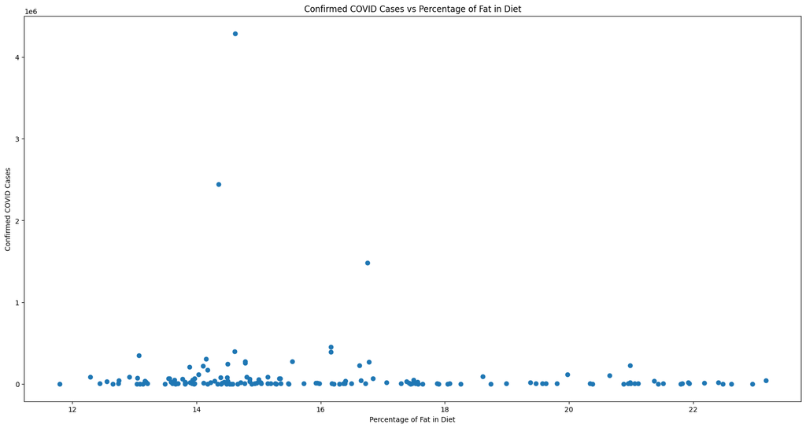

```python
plt.figure(figsize=(20, 10))
plt.xlabel("Percentage of Fat in Diet")
plt.ylabel("Confirmed COVID Cases")
plt.title("Confirmed COVID Cases vs Percentage of Fat in Diet")
plt.plot(df['Fat'], df['Confirmed'], "o")
plt.show()
```

It appears that directly plotting confirmed COVID cases against fat percentage in diet doesn't yield much interesting data. Why could this be the case? It seems that the trend is almost flat; at a first glance, this implies that the percentage of fat doesn't affect the number of COVID cases. However, upon a closer look, we can see that this data is missing a crucial piece of information: the country population! This would explain why there isn't much change in the vertical axis; it's because different countries have vastly different populations, and the scale is much larger! Let's try calculating the *COVID infection rate* by dividing the raw number of cases by the population of the country, and then plotting this data.

In order to do this, we will use the `pypopulation` library to grab population data. Note that we could also do this by scraping data from the web, but this is an easier alternative, as there is no need to clean up the data. Furthermore, we will also scrape the country codes from Wikipedia for our reference.

```python
import pypopulation

codes = pd.read_csv('http://geohack.net/gis/wikipedia-iso-country-codes.csv')
codes.rename(columns={'English short name lower case': "Country"}, inplace=True)
codes.drop(columns=['ISO 3166-2', 'Alpha-3 code', 'Numeric code'], inplace=True)

df = pd.merge(df, codes, on='Country', how='inner')
```

```python
df['Population'] = df.apply(lambda row: pypopulation.get_population(str(row['Alpha-2 code'])), axis=1)
```

Awesome! Now that we have this information, we can normalize the COVID data by dividing by population, and multiplying by a constant factor (say, 100,000). While we're at it, we'll also create a new dataframe and drop the columns that are no longer of interest to tidy things up.

```python
columns_to_get_rid_of = fat_supply_names + protein_supply_names + food_supply_names
for i in range(3):
    columns_to_get_rid_of.remove('Country')
df_useful = df.drop(columns=columns_to_get_rid_of)
df_useful['Confirmed Rate'] = df_useful.apply(lambda row: (row['Confirmed']/row['Population']) * 100000, axis=1)
df_useful['Death Rate'] = df_useful.apply(lambda row: (row['Deaths']/row['Population']) * 100000, axis=1)
df_useful['Recovery Rate'] = df_useful.apply(lambda row: (row['Recovered']/row['Population']) * 100000, axis=1)
df_useful.drop(columns=['Confirmed', 'Deaths', 'Recovered', 'Active'], inplace=True)
df_useful.rename(columns={'Alpha-2 code': 'Code'}, inplace=True)
df_useful
```

|  | Country | Protein | Fat | Code | Population | Confirmed Rate | Death Rate | Recovery Rate |
| --- | --- | --- | --- | --- | --- | --- | --- | --- |
| 0 | Afghanistan | 26.746651 | 16.399524 | AF | 38041754.0 | 95.324206 | 3.335808 | 66.237745 |
| 1 | Albania | 16.225531 | 14.936665 | AL | 2854191.0 | 170.976645 | 5.045212 | 96.174363 |
| 2 | Algeria | 20.743251 | 17.38691 | DZ | 43053054.0 | 64.973323 | 2.701318 | 43.752994 |
| 3 | Angola | 19.655484 | 17.570934 | AO | 31825295.0 | 2.985047 | 0.128828 | 0.760401 |
| 4 | Antigua and Barbuda | 13.736738 | 13.810981 | AG | 97118.0 | 88.552071 | 3.089026 | 66.928891 |
| ... | ... | ... | ... | ... | ... | ... | ... | ... |
| 139 | Uruguay | 15.902623 | 14.397512 | UY | 3461734.0 | 34.722483 | 1.011054 | 27.471781 |
| 140 | Uzbekistan | 18.070651 | 14.442307 | UZ | 33580650.0 | 63.158396 | 0.360327 | 34.764068 |
| 141 | Yemen | 28.093969 | 20.955108 | YE | 29161922.0 | 5.798658 | 1.656269 | 2.856465 |
| 142 | Zambia | 24.744934 | 21.826683 | ZM | 17861030.0 | 25.485652 | 0.783829 | 15.760569 |
| 143 | Zimbabwe | 24.963131 | 20.338912 | ZW | 14645468.0 | 18.463049 | 0.245810 | 3.700804 |

144 rows × 8 columns

With all of this, we can return back to the task of plotting the confirmed COVID case rate against percentage fat consumption in data. We'll also add labels for countries.

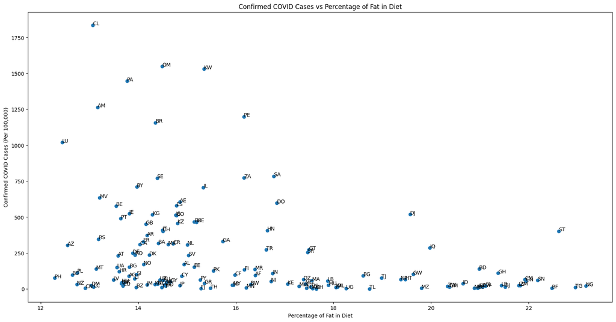

```python
plt.figure(figsize=(20, 10))
plt.xlabel("Percentage of Fat in Diet")
plt.ylabel("Confirmed COVID Cases (Per 100,000)")
plt.title("Confirmed COVID Cases vs Percentage of Fat in Diet")
fat = list(df_useful['Fat'])
confirmed = list(df_useful['Confirmed Rate'])
codes = list(df_useful['Code'])
plt.plot(fat, confirmed, 'o')
for j, txt in enumerate(codes):
    if txt != None:
        plt.annotate(txt, (fat[j], confirmed[j]))
plt.show()
```

Let's do the same, but with the percent consumption of protein:

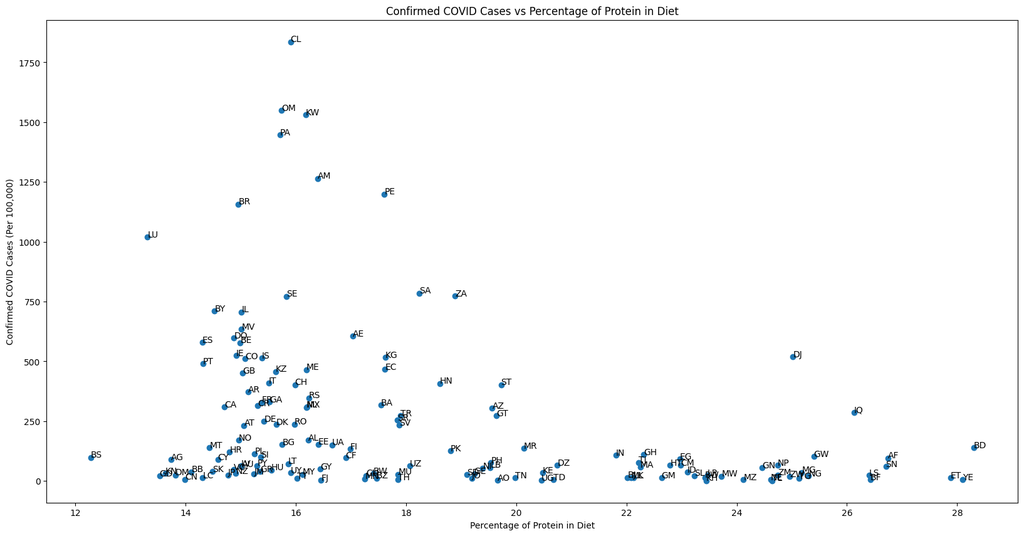

```python
plt.figure(figsize=(20, 10))
plt.xlabel("Percentage of Protein in Diet")
plt.ylabel("Confirmed COVID Cases (Per 100,000)")
plt.title("Confirmed COVID Cases vs Percentage of Protein in Diet")
protein = list(df_useful['Protein'])
confirmed = list(df_useful['Confirmed Rate'])
codes = list(df_useful['Code'])
plt.plot(protein, confirmed, 'o')
for j, txt in enumerate(codes):
    if txt != None:
        plt.annotate(txt, (protein[j], confirmed[j]))
plt.show()
```

This is an interesting trend; for both of these metrics, it seems that more confirmed COVID cases occur when the percentage of fat/protein is lower. Let's make similar plots for death rate and recovery rate to see if this trend continues:

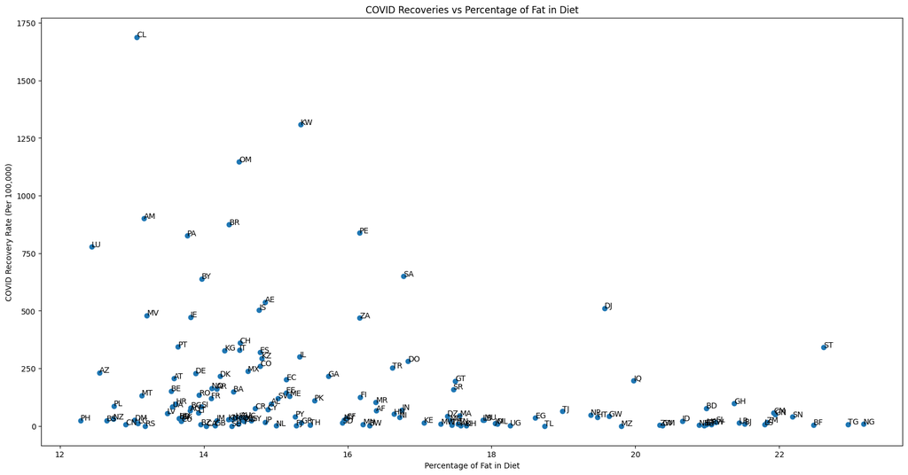

```python
plt.figure(figsize=(20, 10))
plt.xlabel("Percentage of Fat in Diet")
plt.ylabel("COVID Recovery Rate (Per 100,000)")
plt.title("COVID Recoveries vs Percentage of Fat in Diet")
fat = list(df_useful['Fat'])
recovered = list(df_useful['Recovery Rate'])
codes = list(df_useful['Code'])
plt.plot(fat, recovered, 'o')
for j, txt in enumerate(codes):
    if txt != None:
        plt.annotate(txt, (fat[j], recovered[j]))
plt.show()
```

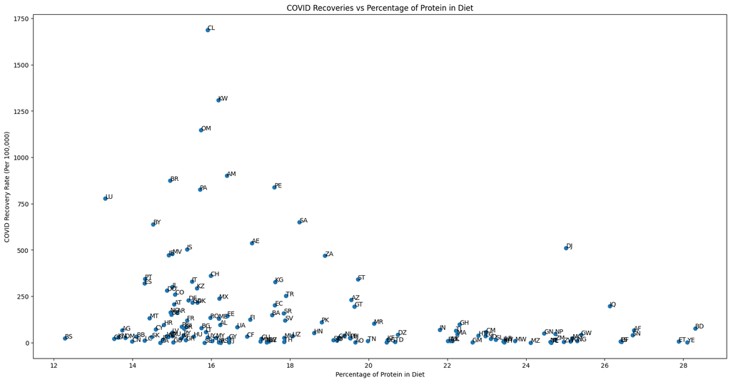

```python
plt.figure(figsize=(20, 10))
plt.xlabel("Percentage of Protein in Diet")
plt.ylabel("COVID Recovery Rate (Per 100,000)")
plt.title("COVID Recoveries vs Percentage of Protein in Diet")
protein = list(df_useful['Protein'])
recovered = list(df_useful['Recovery Rate'])
codes = list(df_useful['Code'])
plt.plot(protein, recovered, 'o')
for j, txt in enumerate(codes):
    if txt != None:
        plt.annotate(txt, (protein[j], recovered[j]))
plt.show()
```

Our data seems to follow a similar trend here; finally, let's handle the COVID death data:

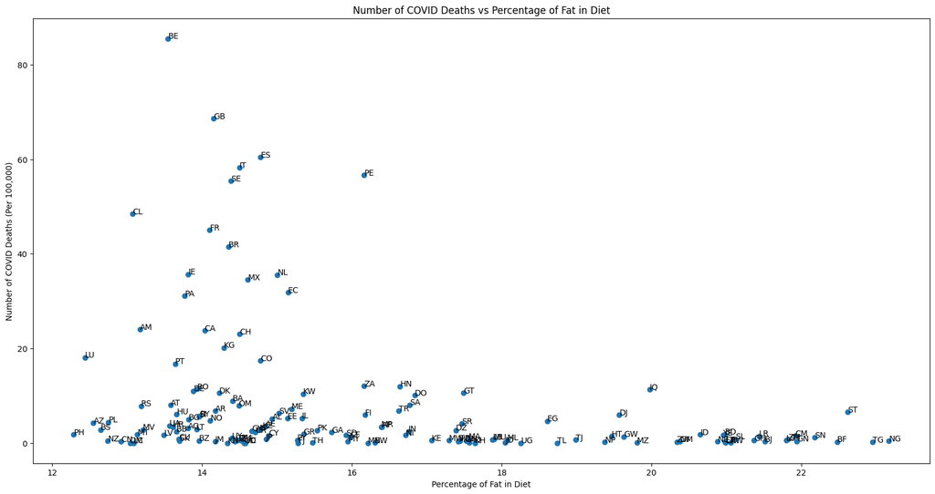

```python
plt.figure(figsize=(20, 10))
plt.xlabel("Percentage of Fat in Diet")
plt.ylabel("Number of COVID Deaths (Per 100,000)")
plt.title("Number of COVID Deaths vs Percentage of Fat in Diet")
fat = list(df_useful['Fat'])
deaths = list(df_useful['Death Rate'])
codes = list(df_useful['Code'])
plt.plot(fat, deaths, 'o')
for j, txt in enumerate(codes):
    if txt != None:
        plt.annotate(txt, (fat[j], deaths[j]))
plt.show()
```

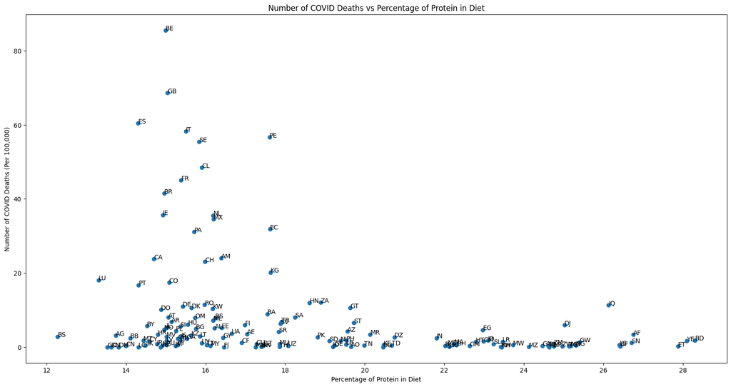

```python
plt.figure(figsize=(20, 10))
plt.xlabel("Percentage of Protein in Diet")
plt.ylabel("Number of COVID Deaths (Per 100,000)")
plt.title("Number of COVID Deaths vs Percentage of Protein in Diet")
protein = list(df_useful['Protein'])
deaths = list(df_useful['Death Rate'])
codes = list(df_useful['Code'])
plt.plot(protein, deaths, 'o')
for j, txt in enumerate(codes):
    if txt != None:
        plt.annotate(txt, (protein[j], deaths[j]))
plt.show()
```

## 4. Hypothesis Testing

In this scenario, the null hypothesis is that there is no statistically significant relationship between fat/protein consumption and COVID numbers. In other words, the null hypothesis asserts that any correlation is due to chance.

In order to analyze the effectiveness of our data, let's perform a linear regression for each of the six combinations of data that we considered. We can perform this using `statsmodels`, and extract the relevant information when needed.

```python
y_death = np.nan_to_num(np.array(deaths))
x_protein = np.nan_to_num(np.array(protein))
x_protein = sm.add_constant(x_protein)

protein_death = sm.OLS(y_death, x_protein).fit()
intercept_p_value = protein_death.pvalues[0]
death_p_value = protein_death.pvalues[1]
print(protein_death.summary())
# Look at the 'coef' column for the line-of-best-fit; the model tells us the equation!
print()
b, m = protein_death.params
print("y = " + str(m) + "*x + " + str(b))
print("p-value is " + str(death_p_value))
```

```
                            OLS Regression Results
==============================================================================
Dep. Variable:                      y   R-squared:                       0.093
Model:                            OLS   Adj. R-squared:                  0.086
Method:                 Least Squares   F-statistic:                     14.52
Date:                Fri, 16 Dec 2022   Prob (F-statistic):           0.000206
Time:                        18:27:01   Log-Likelihood:                -588.16
No. Observations:                 144   AIC:                             1180.
Df Residuals:                     142   BIC:                             1186.
Df Model:                           1
Covariance Type:            nonrobust
==============================================================================
                 coef    std err          t      P>|t|      [0.025      0.975]
------------------------------------------------------------------------------
const         29.6414      5.765      5.141      0.000      18.244      41.039
x1            -1.1639      0.305     -3.810      0.000      -1.768      -0.560
==============================================================================
Omnibus:                       96.964   Durbin-Watson:                   2.290
Prob(Omnibus):                  0.000   Jarque-Bera (JB):              486.287
Skew:                           2.583   Prob(JB):                    2.54e-106
Kurtosis:                      10.373   Cond. No.                         90.4
==============================================================================

Notes:
[1] Standard Errors assume that the covariance matrix of the errors is correctly specified.

y = -1.1638671744134117*x + 29.64136390041183
p-value is 0.0002061082940111262
```

As an example, we print the summary of the regression results above. In the example, the explanatory variable is percentage of protein consumption in diet, and the response variable is the number of COVID deaths per hundred thousand. We can see that the slope term is negative, supporting the conjecture that an increase of protein percentage in diet contributes to a decrease in COVID deaths.

Furthermore, the p-value is less than 0.05, indicating that the results are statistically significant for this combination with an alpha value of 0.05.

Because we don't need to print out the summary statistics each time, let's write a method to perform the linear regression and store the results in a dataframe:

```python
def linear_regression (x, y, explanatory, response):
    y = np.nan_to_num(np.array(y))
    x = np.nan_to_num(np.array(x))
    x = sm.add_constant(x)
    model = sm.OLS(y, x).fit()
    intercept_p_value = model.pvalues[0] # we dont need this
    p_value = model.pvalues[1]
    b, m = model.params
    equation = "y = " + str(m) + "*x + " + str(b)
    return np.array([explanatory, response, equation, p_value])

combinations = [[protein, deaths, 'Protein', 'COVID Deaths'], [protein, confirmed, 'Protein', 'COVID Cases'], [protein, recovered, 'Protein', 'COVID Recoveries'], [fat, deaths, 'Fat', 'COVID Deaths'], [fat, confirmed, 'Fat', 'COVID Cases'], [fat, recovered, 'Fat', 'COVID Recoveries']]
results = np.array([[0, 0, 0, 0]])
for combination in combinations:
    y = combination[1]
    x = combination[0]
    explanatory = combination[2]
    response = combination[3]
    res = linear_regression(x, y, explanatory, response)
    results = np.append(results, [res], axis=0)
results = results[1:]
```

```python
res_df_cols = ['Explanatory Variable', 'Response Variable', 'Least Squares Regression Line', 'P-value']

df_linreg = pd.DataFrame(results, columns=res_df_cols)

df_linreg
```

|  | Explanatory Variable | Response Variable | Least Squares Regression Line | P-value |
| --- | --- | --- | --- | --- |
| 0 | Protein | COVID Deaths | y = -1.1638671744134117*x + 29.64136390041183 | 0.0002061082940111262 |
| 1 | Protein | COVID Cases | y = -28.142411476458875*x + 759.7186314599451 | 7.922440561464265e-05 |
| 2 | Protein | COVID Recoveries | y = -17.637673860535614*x + 482.07359461287433 | 0.0014640752427746734 |
| 3 | Fat | COVID Deaths | y = -1.5864143664992216*x + 33.948009541878754 | 0.0003005635800383212 |
| 4 | Fat | COVID Cases | y = -38.50932038105586*x + 866.2868407551034 | 0.00011376521362740204 |
| 5 | Fat | COVID Recoveries | y = -24.57070372722385*x + 555.9469264315403 | 0.0015208230077863982 |

As we can see in the dataframe above, the results are similar for every combination of explanatory and response variable. We see that in all cases, the slope of the least squares regression line is negative, and the P-value is ≤ 0.05, so that the models have statistical significance with an alpha threshhold of 0.05. In other words, we can reject the null hypothesis, and conclude that there is a statistically significant relationship between each explanatory and response variable considered.

## 5. Communication of insights attained

Initially, I had anticipated that more fat would contribute to worse COVID case/death rates and more protein would contribute to better COVID case/death rates; this is because, classically fat is associated with negative effects and protein is associated with strength, so I thought the former would exacerbate COVID symptoms while the latter would improve them. However, it appears as though this one-dimensional approach does not hold true; rather, a higher dietary percentage of **both** protein and fat is correlated with a decreased in COVID infection and death rate with high statistical significance.

I had also originally thought that healthier food choices would contribute to a greater rate of COVID recovery. This did not turn out to be the case; the trend for COVID recovery was similar to the other response variables. This is probably due to the fact that COVID recovery is also conditional on COVID infection; the former cannot happen without the latter occuring. An interesting extension would be to consider a multi-linear model, and perhaps calculate additional metrics of measuring response variables–for example, dividing the recovery rate by the infection rate.

In spite of the contrast of the data results to my original hypothesis, I do believe it is overall consistent and makes sense; this is because fat is not necessarily always a bad thing! More fat and protein consumption could actually be an indicator of a country's socioeconomic status; more well-off countries would have access to better (and more) food supplies; thus having more access to these food sources would increase the relative percentage composition in diet, and also improve COVID infection/death rates.

All in all, the data do reveal an important point I mentioned earlier: the importance of health amid the COVID-19 pandemic cannot be understated. More so now than ever, having access to healthy food is critical; nourishment is essential to living a healthy life, and as we can see from the data, a lack of presence of important food groups in one's diet can exacerbate the impacts of COVID. Certainly these results can be applied outside of the scope of the COVID pandemic, but it is especially important now to fight hard in the global war against world hunger. After all, health requires healthy food.

## 6: Sources

- https://www.kaggle.com/datasets/mariaren/covid19-healthy-diet-dataset
- https://www.kaggle.com/datasets/imdevskp/corona-virus-report
- Wikipedia
- `pypopulation`